# Project_Red_Wines

LLT

Saturday, May 16, 2015

# Analysis

## First look

We have the following variables:

```
##  [1] "fixed.acidity"        "volatile.acidity"     "citric.acid"
##  [4] "residual.sugar"       "chlorides"            "free.sulfur.dioxide"
##  [7] "total.sulfur.dioxide" "density"              "pH"
## [10] "sulphates"            "alcohol"              "quality"
```

We have 12 variables. And their types:

```
## 'data.frame':    1599 obs. of  12 variables:
##  $ fixed.acidity       : num  7.4 7.8 7.8 11.2 7.4 7.4 7.9 7.3 7.8 7.5 ...
##  $ volatile.acidity    : num  0.7 0.88 0.76 0.28 0.7 0.66 0.6 0.65 0.58 0.5 ...
##  $ citric.acid         : num  0 0 0.04 0.56 0 0 0.06 0 0.02 0.36 ...
##  $ residual.sugar      : num  1.9 2.6 2.3 1.9 1.9 1.8 1.6 1.2 2 6.1 ...
##  $ chlorides           : num  0.076 0.098 0.092 0.075 0.076 0.075 0.069 0.065 0.073 0.071 ...
##  $ free.sulfur.dioxide : num  11 25 15 17 11 13 15 15 9 17 ...
##  $ total.sulfur.dioxide: num  34 67 54 60 34 40 59 21 18 102 ...
##  $ density             : num  0.998 0.997 0.997 0.998 0.998 ...
##  $ pH                  : num  3.51 3.2 3.26 3.16 3.51 3.51 3.3 3.39 3.36 3.35 ...
##  $ sulphates           : num  0.56 0.68 0.65 0.58 0.56 0.56 0.46 0.47 0.57 0.8 ...
##  $ alcohol             : num  9.4 9.8 9.8 9.8 9.4 9.4 9.4 10 9.5 10.5 ...
##  $ quality             : int  5 5 5 6 5 5 5 7 7 5 ...
```

All of them are numeric. 1599 data points.

A first overlook at the data.

```
##  fixed.acidity   volatile.acidity  citric.acid    residual.sugar
##  Min.   : 4.60   Min.   :0.1200   Min.   :0.000   Min.   : 0.900
##  1st Qu.: 7.10   1st Qu.:0.3900   1st Qu.:0.090   1st Qu.: 1.900
##  Median : 7.90   Median :0.5200   Median :0.260   Median : 2.200
##  Mean   : 8.32   Mean   :0.5278   Mean   :0.271   Mean   : 2.539
##  3rd Qu.: 9.20   3rd Qu.:0.6400   3rd Qu.:0.420   3rd Qu.: 2.600
##  Max.   :15.90   Max.   :1.5800   Max.   :1.000   Max.   :15.500
##    chlorides       free.sulfur.dioxide total.sulfur.dioxide
##  Min.   :0.01200   Min.   : 1.00       Min.   :  6.00
##  1st Qu.:0.07000   1st Qu.: 7.00       1st Qu.: 22.00
##  Median :0.07900   Median :14.00       Median : 38.00
##  Mean   :0.08747   Mean   :15.87       Mean   : 46.47
##  3rd Qu.:0.09000   3rd Qu.:21.00       3rd Qu.: 62.00
##  Max.   :0.61100   Max.   :72.00       Max.   :289.00
##     density             pH          sulphates         alcohol
##  Min.   :0.9901   Min.   :2.740   Min.   :0.3300   Min.   : 8.40
##  1st Qu.:0.9956   1st Qu.:3.210   1st Qu.:0.5500   1st Qu.: 9.50
##  Median :0.9968   Median :3.310   Median :0.6200   Median :10.20
##  Mean   :0.9967   Mean   :3.311   Mean   :0.6581   Mean   :10.42
##  3rd Qu.:0.9978   3rd Qu.:3.400   3rd Qu.:0.7300   3rd Qu.:11.10
##  Max.   :1.0037   Max.   :4.010   Max.   :2.0000   Max.   :14.90
##     quality
##  Min.   :3.000
##  1st Qu.:5.000
##  Median :6.000
##  Mean   :5.636
##  3rd Qu.:6.000
##  Max.   :8.000
```

The summary shows max really far out for residual.sugar, chlorides, free.sulfur, density… Those might be outlier/reporting problem or really special wines.

### Quality

First of all, what about quality of those red wines Also, quality is a numeric, we will add it as a factor.

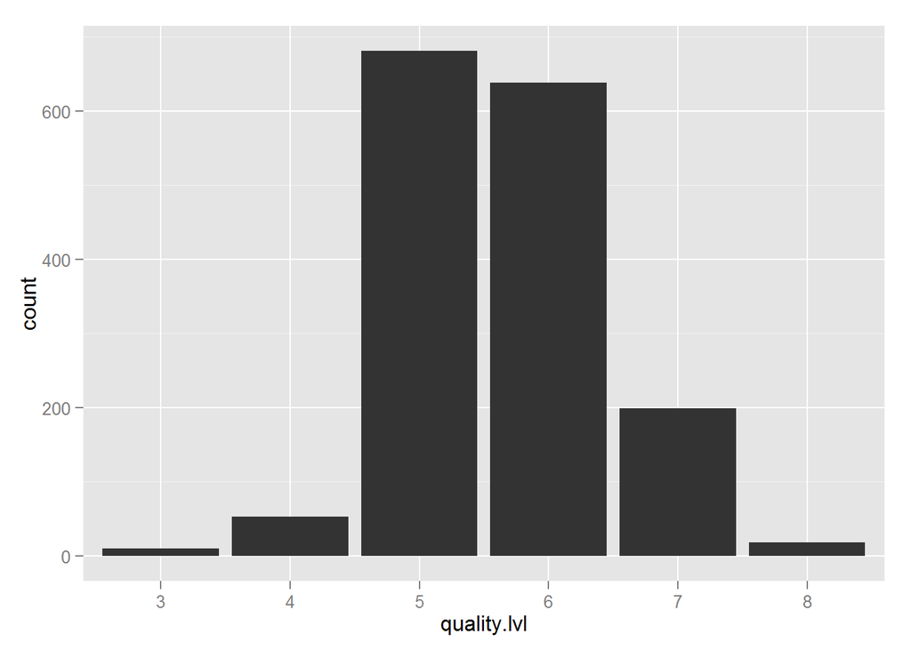

It looks like a normal distribution. Notes are out of 10. Most of the wines are around 5/6.

### Alcohol

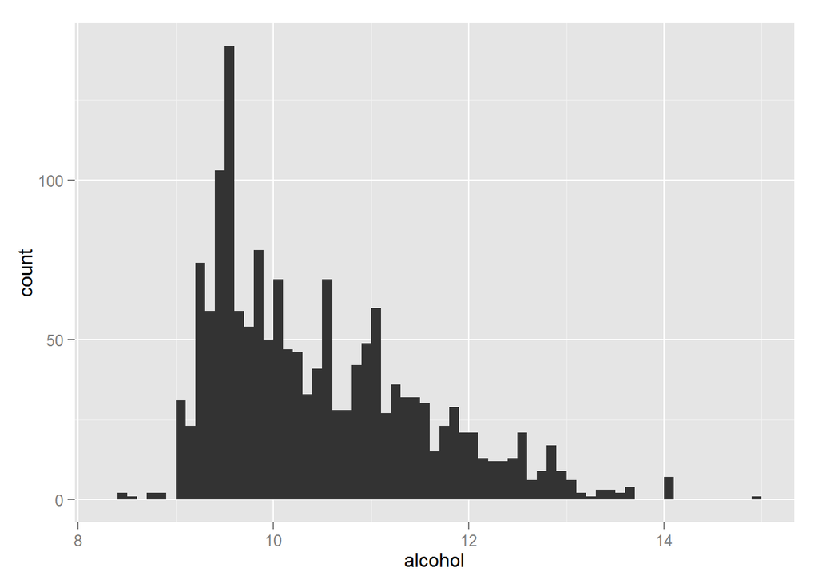

Much more disparate but we have a nice peak around 9.5% by volume. All in all it still looks like a normal distribution.

### Residual Sugar

Residual sugar is the amount of sugar remaining after fermentation.

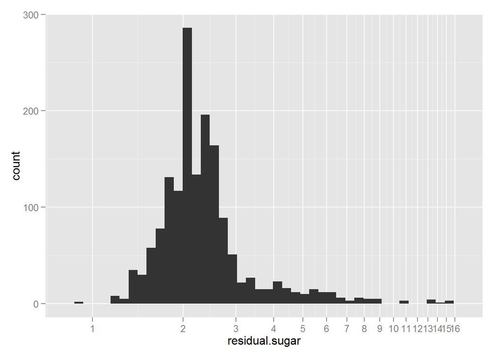

```
##    Min. 1st Qu.  Median    Mean 3rd Qu.    Max.
##   0.900   1.900   2.200   2.539   2.600  15.500
```

Max is at 15 while the 3rd quartile is at 2.6 and the median at 2.2. So those are quite special wines or there is some error in the data.

### Chlorides

Chlorides is salt. I woud consider not a great taste in wine.

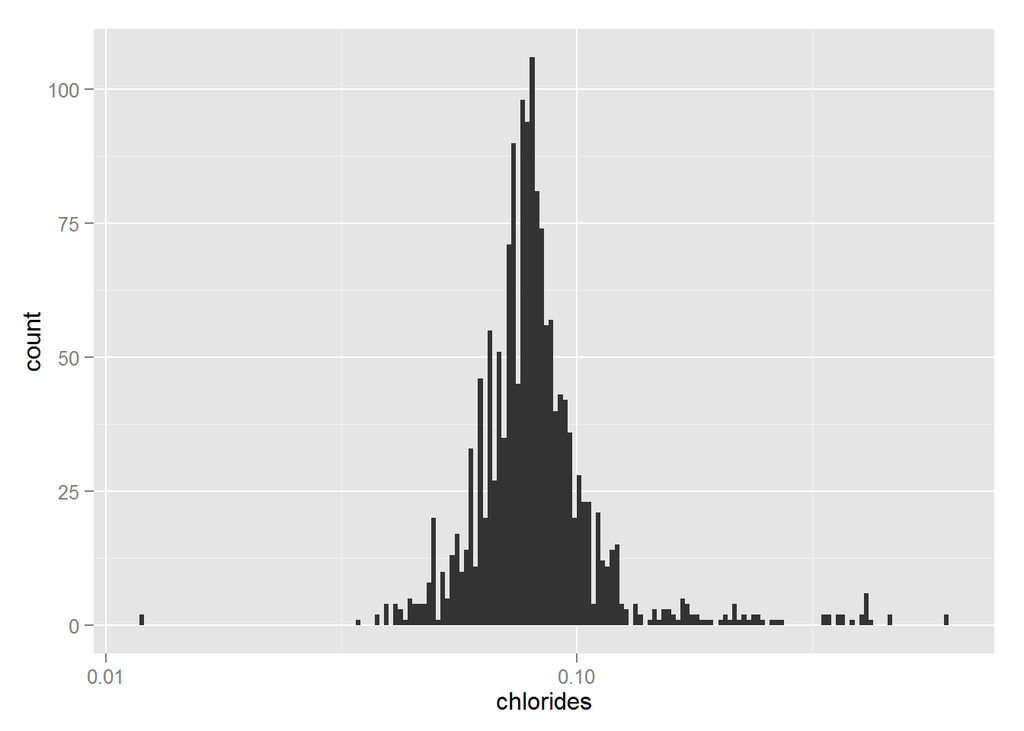

We have a normal distribution once the x axis is transformed using a log10 function. Like residual.sugar, we have a longtail of data.

```
##    Min. 1st Qu.  Median    Mean 3rd Qu.    Max.
## 0.01200 0.07000 0.07900 0.08747 0.09000 0.61100
```

The unit is the same as the residual.sugar but the number are way lower. Median is at 0.079g / dm^3. The max is more than 7 time higher.

### Citric acid

In small quantities, citric acid can add freshness and pops to wine.

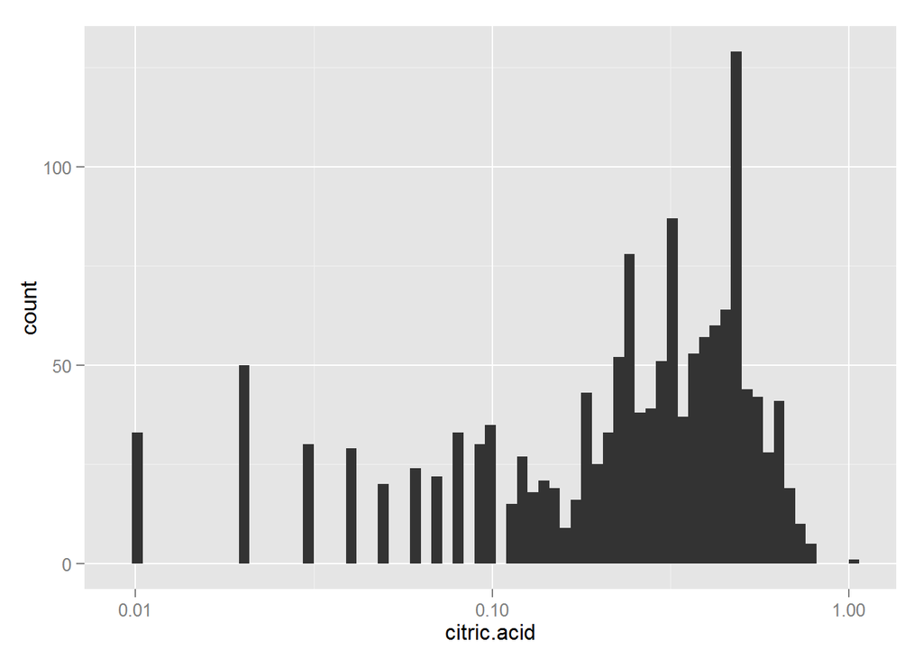

```
##    Min. 1st Qu.  Median    Mean 3rd Qu.    Max.
##   0.000   0.090   0.260   0.271   0.420   1.000
```

Once again we have a median at 0.26 g/dm^3 whereas the max is at 1 and the min is at 0.

### pH

pH scale from 0 (very acid) to 14 (very basic). Most wines are between 3 and 4.

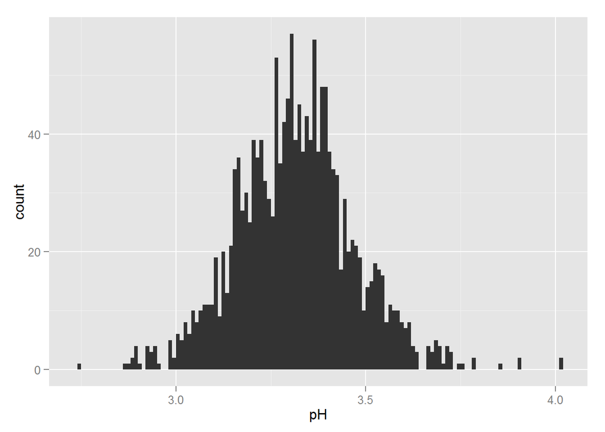

The pH is normally distributed with a peak without the need for a log scale. We can see that the data is quite disperse but that as the description says, most of the data points are between 3 and 4.

```
##    Min. 1st Qu.  Median    Mean 3rd Qu.    Max.
##   2.740   3.210   3.310   3.311   3.400   4.010
```

The min and max are once again quite far apart from the median and the 1st and 3rd quartiles respectively.

### Volatile acidity

Volatile acidity is the amoutn acetic acid in wine. At high concentration it gives an unpleasant vinegar taste which, I think, is what a low quality wine taste like.

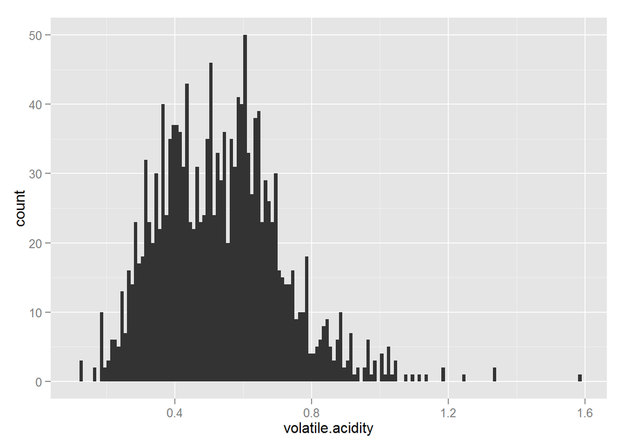

Still a long tail in the data with a peak around 0.6 g / dm^3 of acetic acid.

```
##    Min. 1st Qu.  Median    Mean 3rd Qu.    Max.
##  0.1200  0.3900  0.5200  0.5278  0.6400  1.5800
```

The max is really out of range of the other data points. Median is at 0.52 g / dm^3 of acetic acid and the mean is quite similar ar 0.5278 g / dm^3 of acetic acid.

### Total Sulfur Dioxide

Total sulfur dioxide is the sum of free (to oxidation of wine) and bound forms of sulfur. At high concentration is can influence taste.

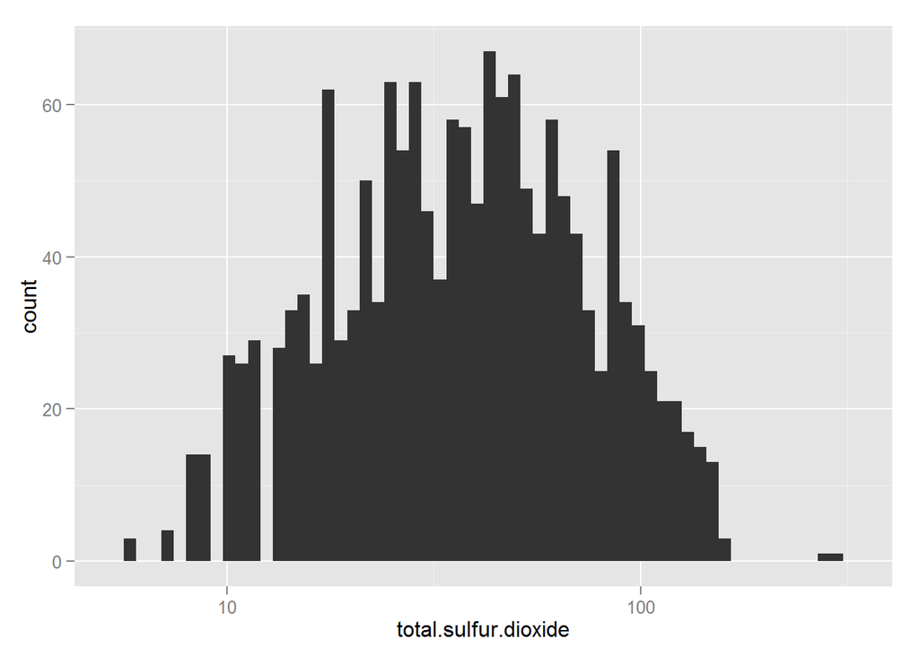

The x axis is transformed using log10. We have several bumps but overall a normal distribution. Some data points seem to be isolated. Let’s look at the variable summary.

```
##    Min. 1st Qu.  Median    Mean 3rd Qu.    Max.
##    6.00   22.00   38.00   46.47   62.00  289.00
```

The max is really too high compared to the median and the 3rd quartile. It is an error in data reporting/recording I think.

My main line of inquiries will be the relation between all variables to quality.

## Bivariate analysis

### Alcohol and quality

Does alcohol level affects the quality?

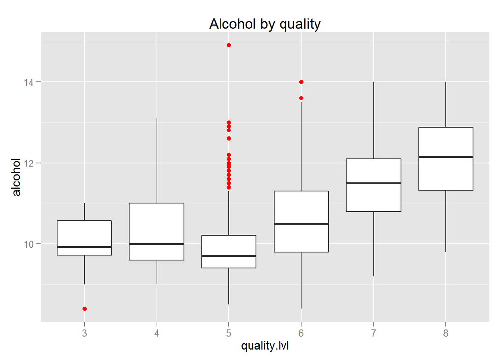

```
## [1] 0.4761663
```

There is a medium correlation (around 0.48) between quality and alcohol, the graph shows that the higher the quality, the higher the alcohol. This is especially true for the higher end wines.

### Acidity variables

We have 3 types of acidity listed:

- Fixed acidity: most acids involved with wine or fixed or nonvolatile (do not evaporate readily)
- Volatile acidity: the amount of acetic acid in wine, which at too high of levels can lead to an unpleasant, vinegar tast
- Citric acid: found in small quantities, citric acid can add ‘freshness’ and flavor to wines

They should all relate to the ph I think.

```
## [1] -0.6829782
```

```
## [1] 0.2349373
```

```
## [1] -0.5419041
```

So Fixed acidity and citric acid correlate quite strongly with the pH (around -0.68 and -0.54 respectively), but not the volatile acidity (around 0.23).

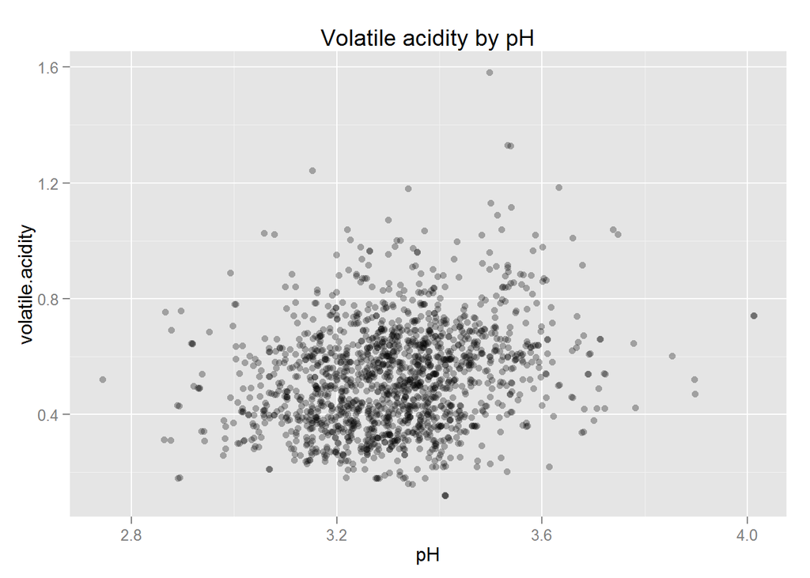

Volatile acidity and pH are not related. Even for high quality wines, the pH seems to vary greatly. This confirms the low correlation previously found.

### Quality and pH

Let’s get a closer look between those pH and quality now.

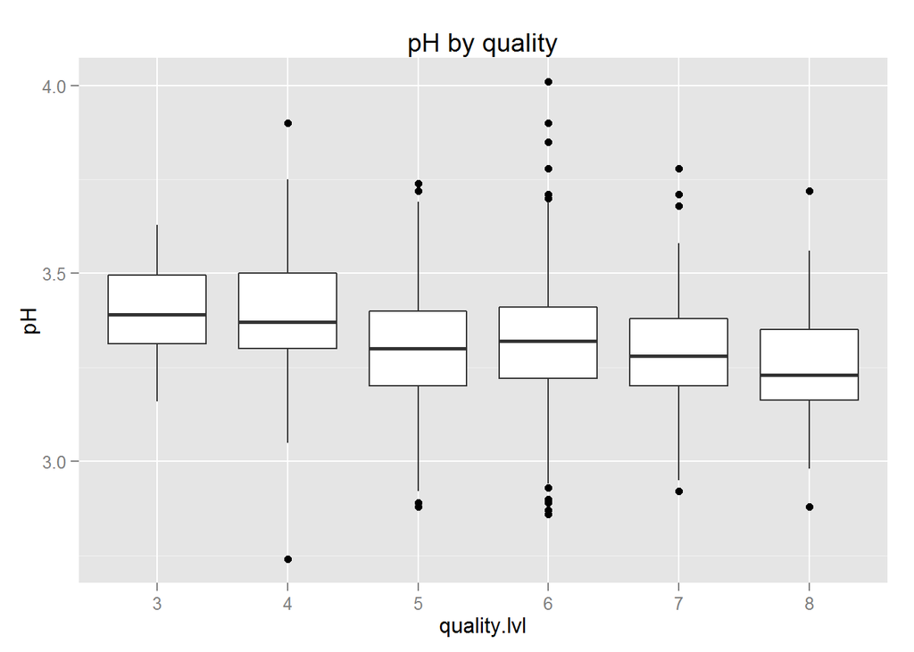

The higher the quality, the lower the pH it seems.

```
## [1] -0.05773139
```

The correlation coefficient between the two is very low at -0.06. So the first impression of the plot is not validated by the number in fact.

What about salt?

### Quality and chlorides

As a reminder, the chlorides summary.

```
##    Min. 1st Qu.  Median    Mean 3rd Qu.    Max.
## 0.01200 0.07000 0.07900 0.08747 0.09000 0.61100
```

The summary shows that the max is at 0.611 whereas the 3rd quartile is at 0.09. Lets zoom in to have a better view.

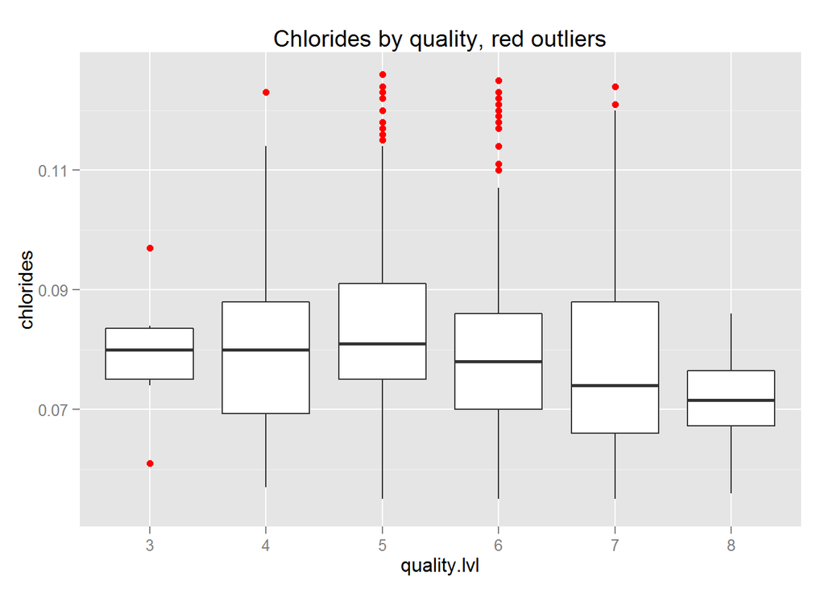

The plot is limited between the 0.05 and the 0.95 quantiles. There is some overlaps, but the higher the quality, the least salt.

```
## [1] -0.1289066
```

The correlation is very low at -0.13. So the relationship between the two variables is ot very strong.

Last variable on the obvious affecting taste (and so quality), I think, is sugar.

### Quality and residual sugar

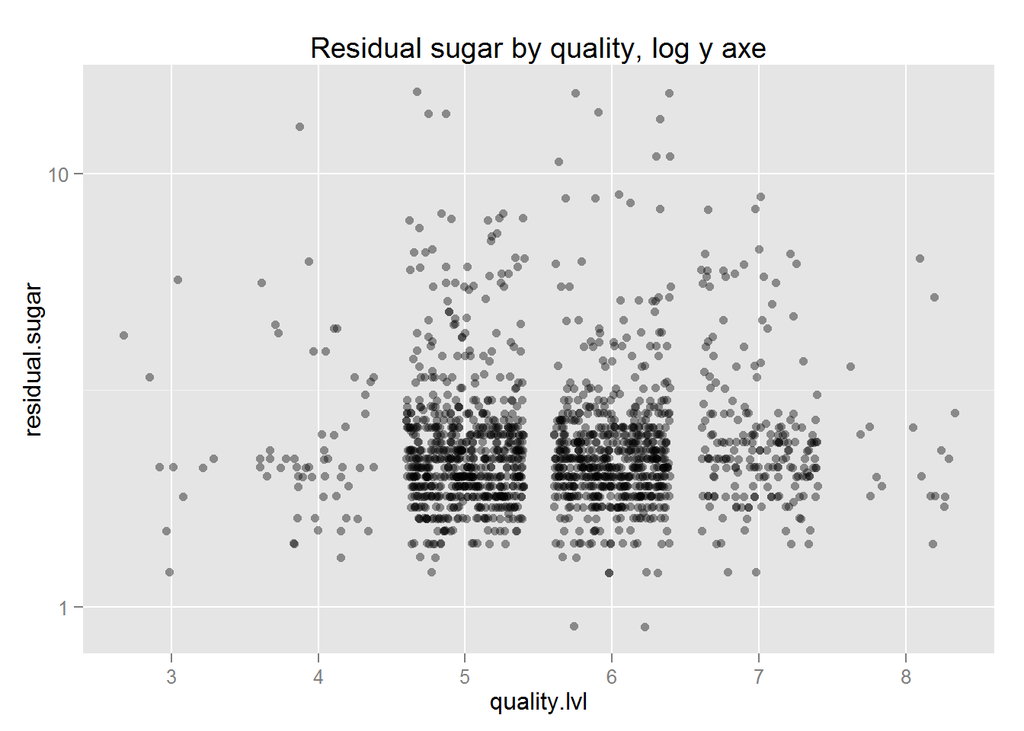

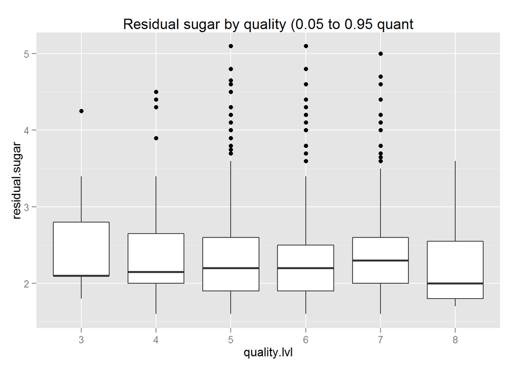

No clear relationship between the sugar and quality. The scatterplot shows points all over the place. As for the boxplot, the median and quartiles do not vary depending of quality.

```
## [1] 0.01373164
```

Correlation confirms that there is no relationships (0.01).

## Multivariate analysis

Let’s try multi-variables plots to see if we can have a better picture.

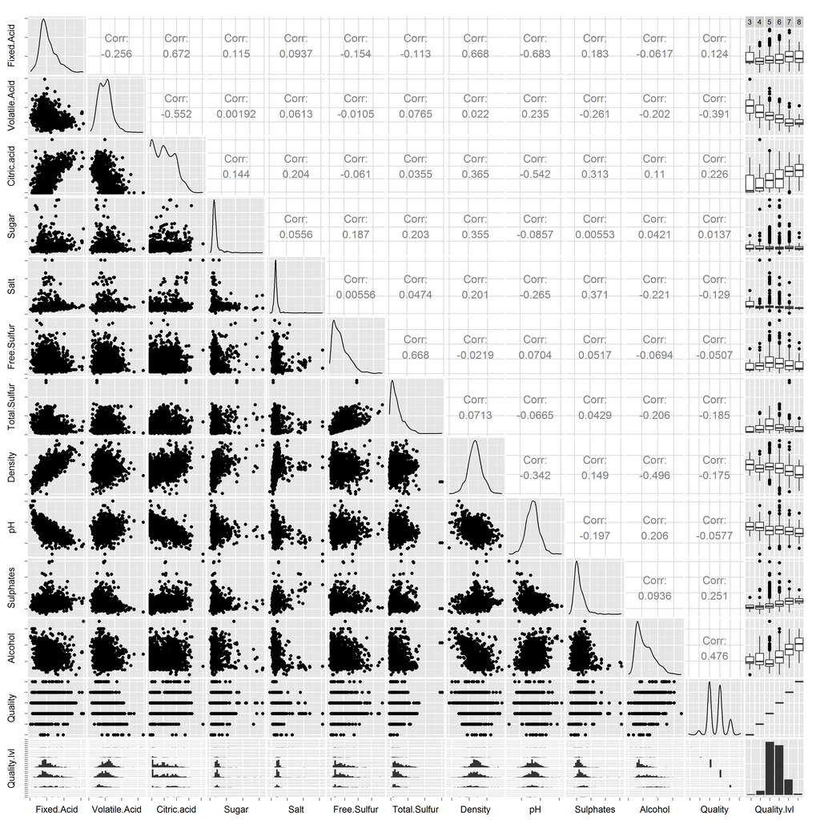

Regarding quality, we can see some correlation with:

- Alcohol (0.476)
- Volatile acidity (-0.391)

As for our quality level we have some nice stepping with:

- Alcohol
- pH
- Citric acid
- Volatile acidity

As the correlation is not very high with some of those variables, we will analyse them afterwards.

I want for the time being have a closer look at chlorides.

### Chlorides and alcohol by quality

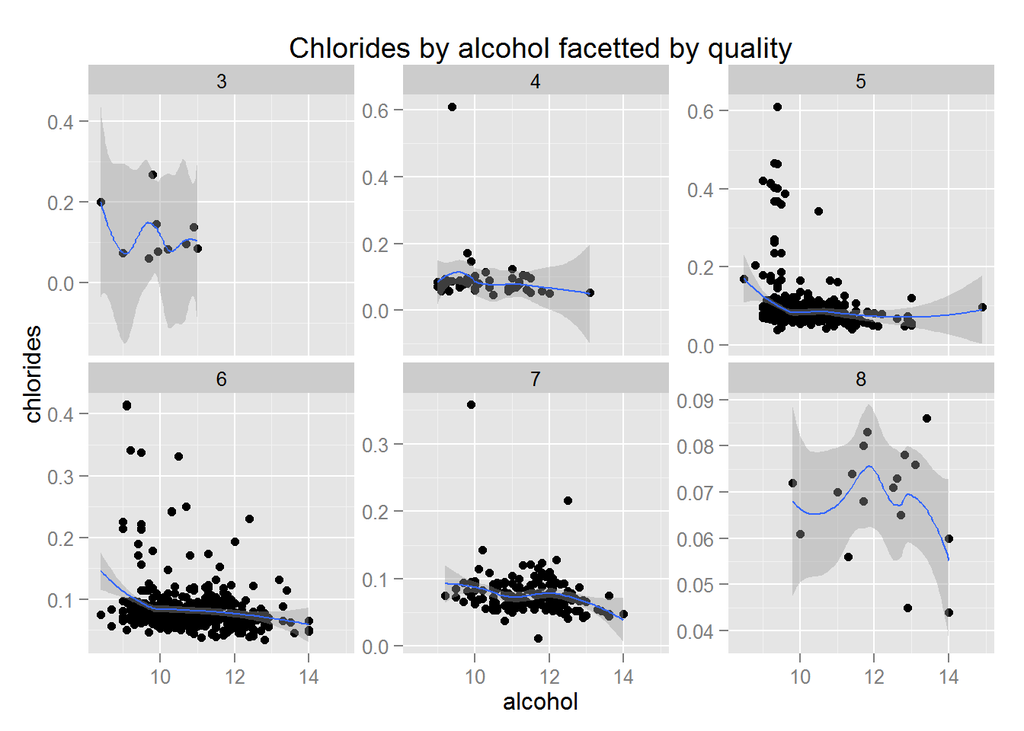

The overall trend is downward: less chlorides as the alcohol level gets higher. But we can see that for the top 2 qualities, we got a rebound around 12° where salt level rises a bit. It might be some outlier as we only got a few points for those quality.

```
## [1] -0.1840977
```

```
## [1] -0.2094449
```

```
## [1] -0.1714213
```

The correlation between chlorides and alcohol are:

- -0.184 for quality 5
- -0.209 for quality 6
- -0.171 for quality 8

Correlations are not really strong and quite constant between the different qualities.

### Residual sugar and alcohol by quality

Let’s look at the same thing with sugar:

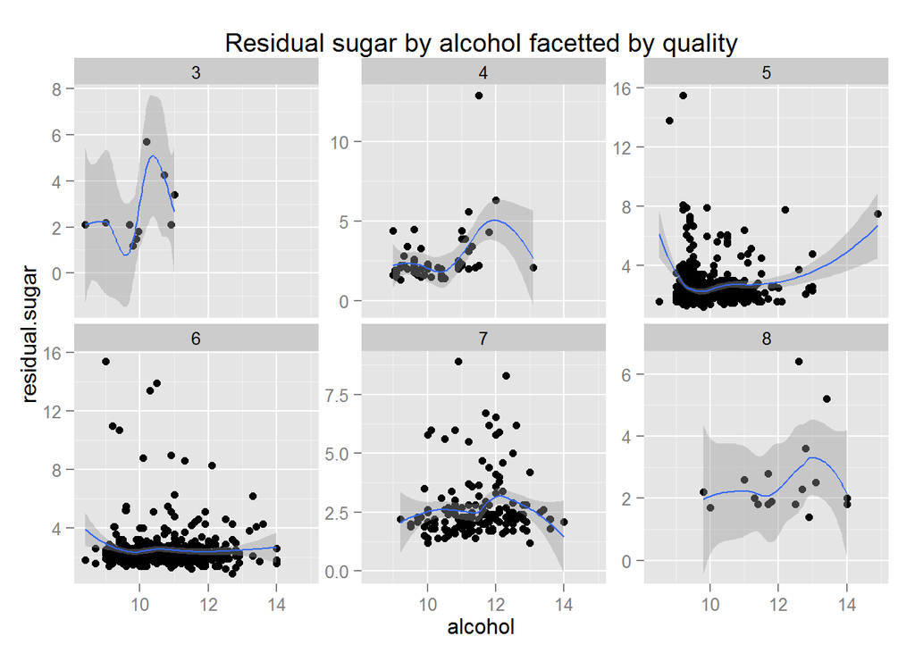

```
## [1] 0.05361262
```

```
## [1] -0.02603628
```

```
## [1] 0.2248001
```

The correlations are really low:

- 0.054 for quality 5
- -0.026 for quality 6
- 0.225 for quality 8

The much higher correlation for quality 8 is kind of interesting but we only have a few data points fior this quyality so the correlation might be due to that.

The trends in the plots for chlorides and residual.sugar look kind of the same. Chlorides and residual sugar might be linked.

### Chlorides and residual sugar by quality

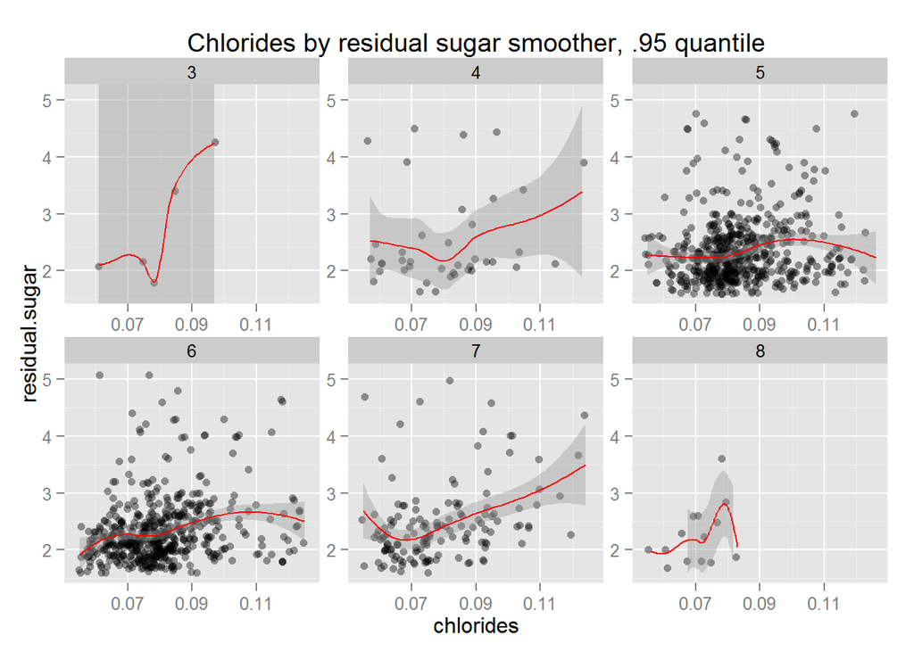

The relation between chlorides and residual sugar seems to go more linear as the quality improves. It might make for better balanced wine in the end.

Let see if the ratio of sugar by chlorides is any help:

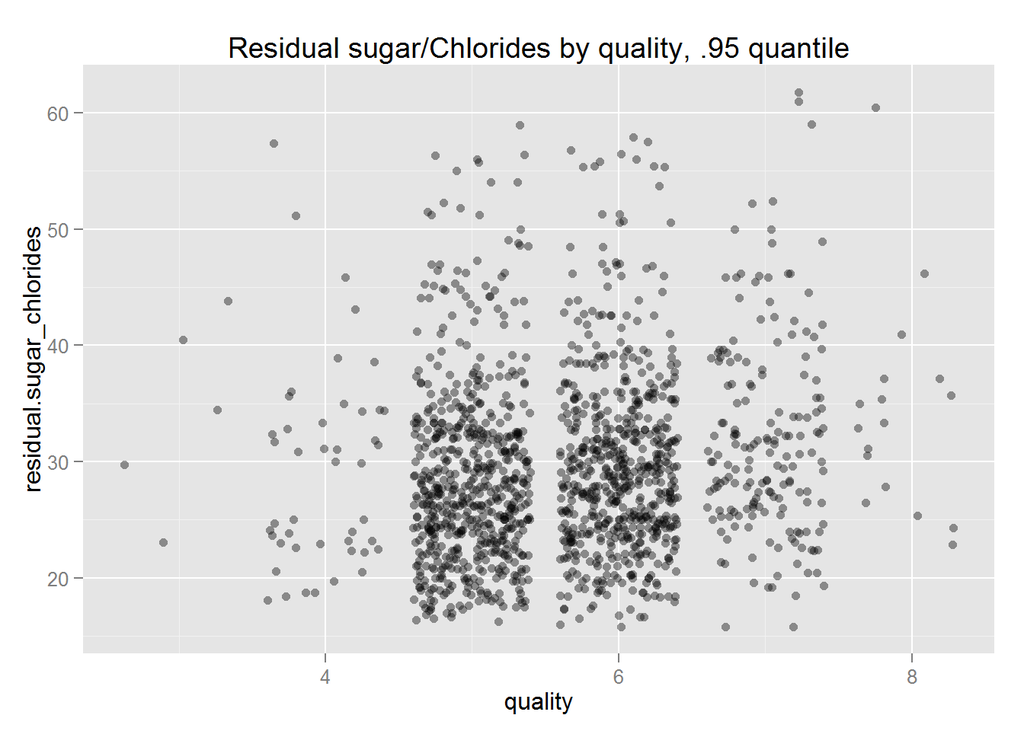

No chance here. I was hoping for some clusters of points for each quality level, but they can vary widely.

```
## [1] 0.03052571
```

```
## [1] 0.109797
```

```
## [1] 0.4833793
```

The correlation for quality 5 and 6 is quite low (0.031 and 0.110 respectively) but the one for 8 is much higher. This might be because we have fewer point on the 8 quality than on other quality level. Furthermore, we have very far off values in both residual.sugar and chlorides, let’s calculate the same value on a subset limited between the .05 and .95 quantiles.

```
## [1] 0.1471444
```

```
## [1] 0.224034
```

```
## [1] 0.4204166
```

- 0.147 for quality 5
- 0.224 for quality 6
- 0.420 for quality 8

I think this relationship between residual sugar and chlorides is worth investigating to see if other variables might come in play. So let’s map chlorides with sugar and add alcohol as a color and use this as a base for other graphs.

### Chlorides, residual sugar and alcohol by quality

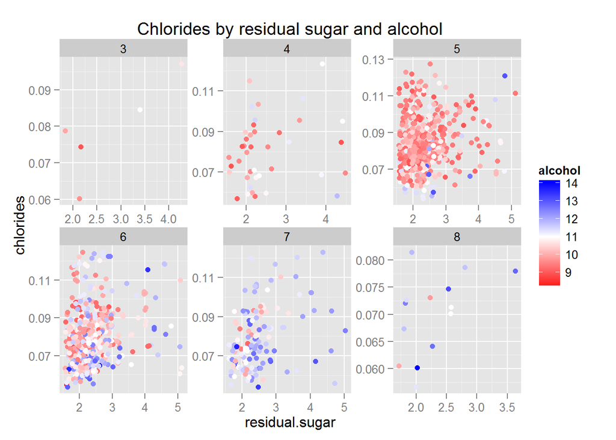

We can see as before that the higher the quality, the more alcohol. Furthermore, low alcohol levels seems to have less sugar (we have cluster of red on the left of the plots and it seems to go bluer as residual.sugar increases).

```
## [1] 0.2565169
```

```
## [1] 0.229428
```

```
## [1] 0.2194511
```

```
## [1] 0.2097588
```

The correlation between residual.sugar_chlorides and alcohol for the subset is 0.257 which is medium. Breaking it up by quality we have:

- 0.229 for quality 5
- 0.219 for quality 6
- 0.210 for quality 8

So the correlation does not vary greatly between quality. We do not have a specific relationship for some qualities.

### Acidity variables and quality

Let’s go back to our acidity variables:

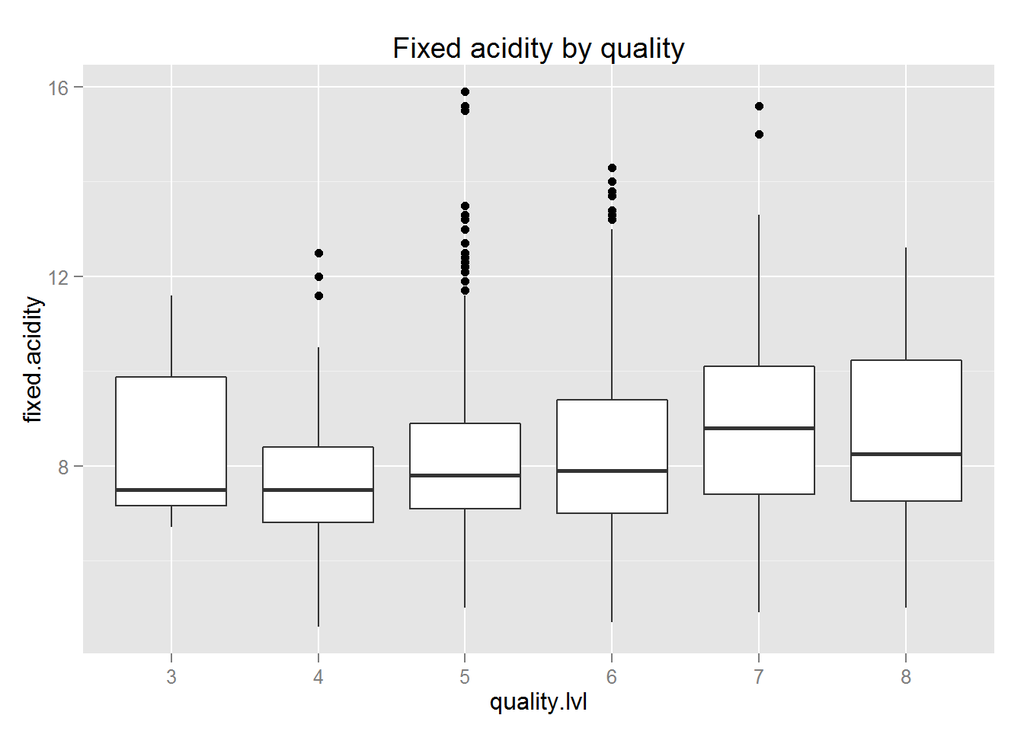

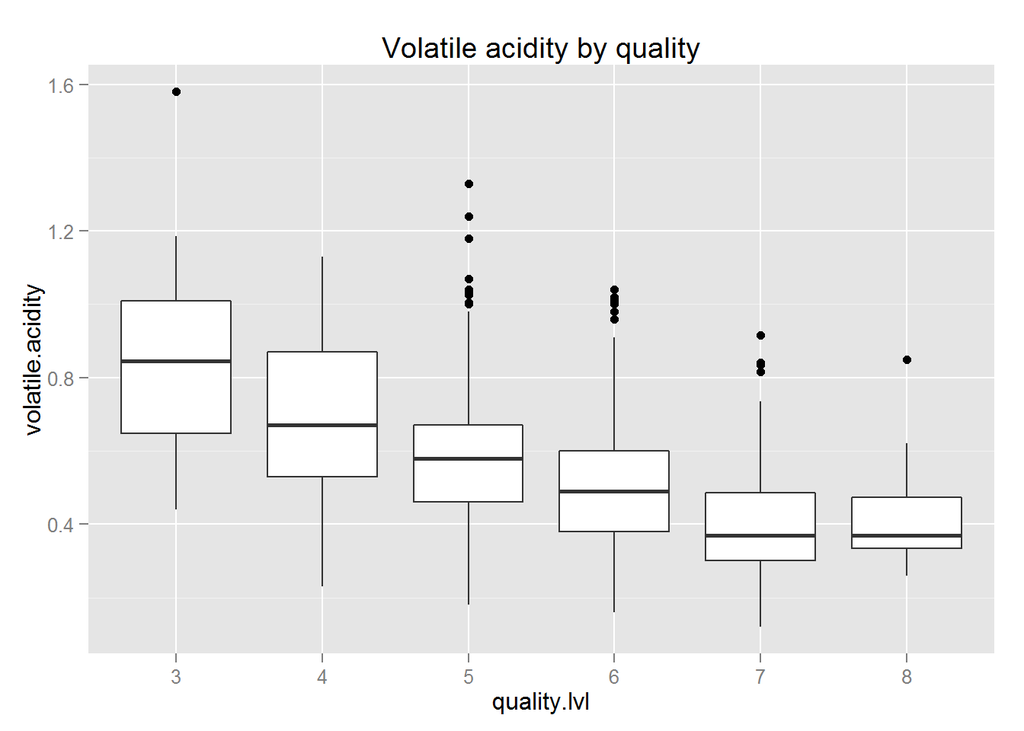

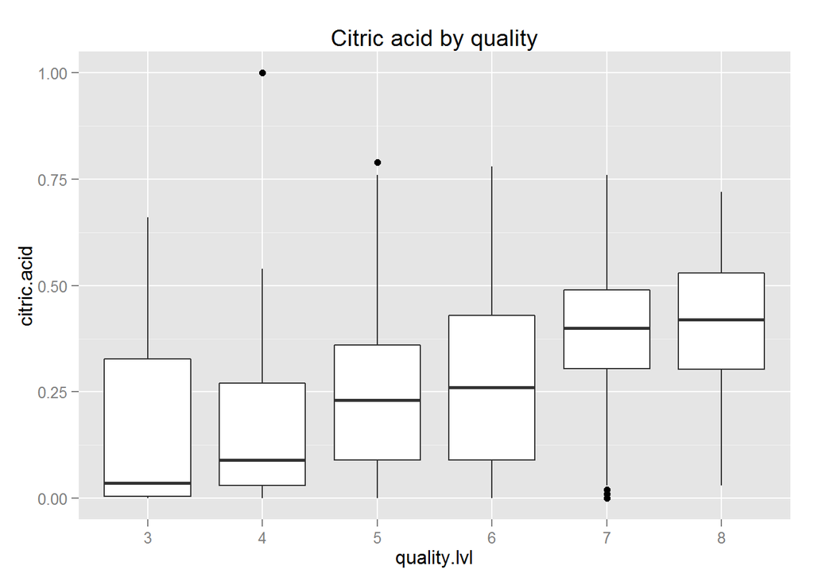

We can see that fixed acidity is not really relevant to quality, but volatile.acidity and citric acid are. The higher the citric acid level, the better the quality. The relation between volatile acidity and quality is the other way around. Futhermore, looking at the median we can see some group of qualities: 3 & 4, 5 & 6 and 7 & 8.

```
## [1] 0.1240516
```

```
## [1] -0.3905578
```

```
## [1] 0.2263725
```

Correlation confirms that fixed acidity correlates only weakly with the quality (0.124). On the other hand, volatile acidity (-0.391) and citric acid (0.226) are much stronger, especially volatile acidity. This kind of acidity correlates negatively with quality meaning that as the quality improves, the volatile acidity decreases. The vinegar taste brought by volatile acidity is really hurting the quality.

So we now have alcohol, citric acid and volatile acidity correlating quite strongly with quality. I will get back to the previous facetted chart of residual sugar and chlorides and add citric acid/volatile acidity to see if I can get some more information.

### Chlorides, residual sugar and acidities by quality

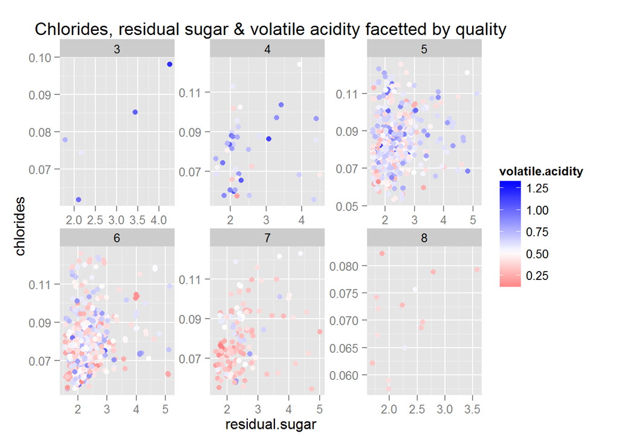

```
## [1] -0.0245989
```

Nothing specialfor volatile acidity which is confirmed by the really low correlation with residual.sugar_chlorides (-0.025).

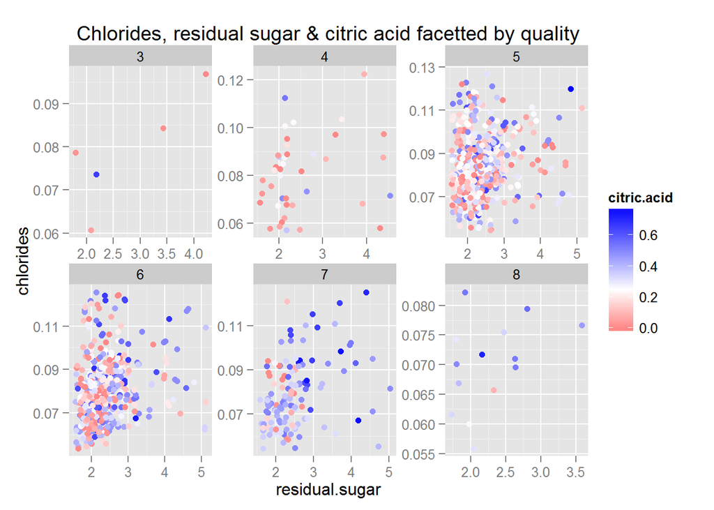

It seems that we get more citric acid the more residual sugar and chlorides in the wine.

```
## [1] 0.09475486
```

```
## [1] 0.0292045
```

```
## [1] 0.1136215
```

```
## [1] -0.02340568
```

Correlations show that there is in fact nothing. The correaltion for our subset is 0.09. Breaking by quality:

- 0.029 for quality 5
- 0.114 for quality 6
- -0.02 for quality 8

### Chlorides, residual sugar and density by quality

Density is related to alcohol so let see if we can find something here.

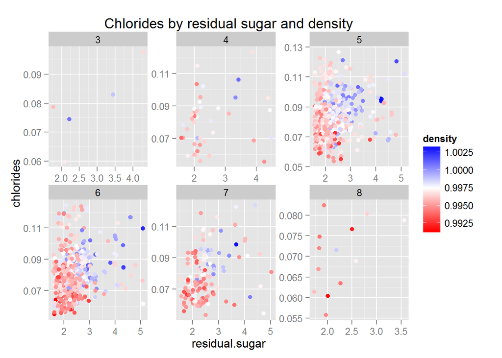

We get the same kind of graph than for alcohol with denser wines on the right of the graphs whereas less dense wines are in the left region.

```
## [1] 0.110786
```

```
## [1] 0.2565169
```

```
## [1] 0.1897605
```

```
## [1] 0.229428
```

Density relates less to the residual.sugar_chlorides ratio than alcohol: 0.111 vs 0.256. We have the same phenomenom for quality 5: 0.190 for density vs 0.229 for alcohol.

### Chlorides, residual sugar and sulphates by quality

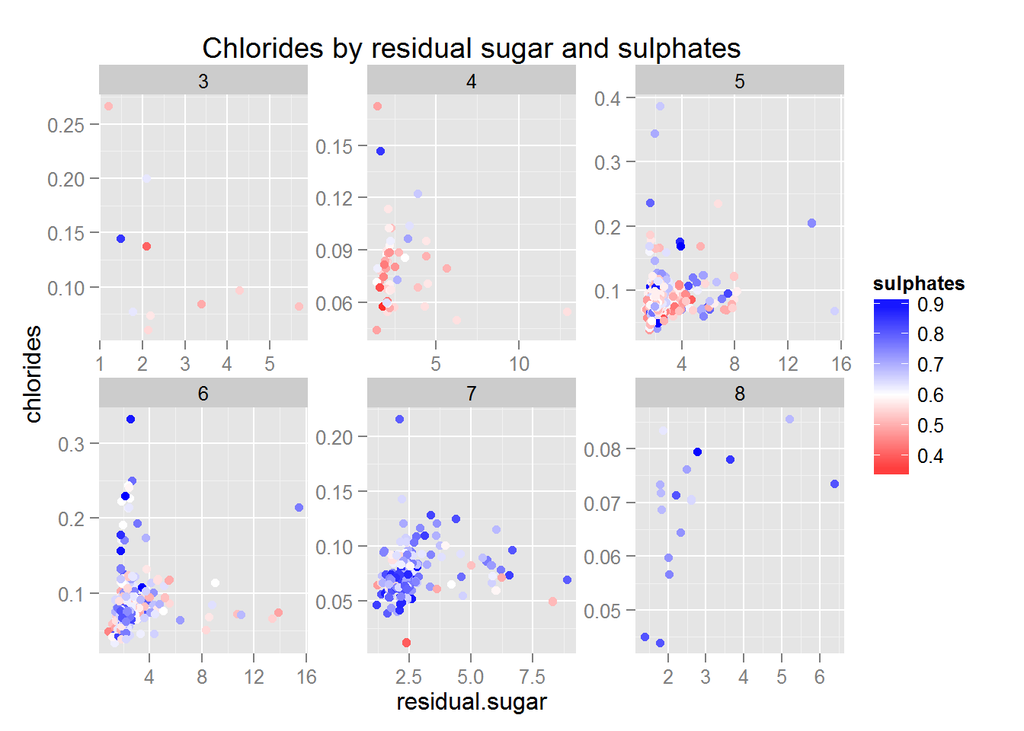

There seems to be more sulphates for higher quality wines, but other than that, nothing with chlorides and residual.sugar.

```
## [1] 0.04507417
```

```
## [1] -0.0357411
```

```
## [1] 0.07618921
```

```
## [1] 0.1550198
```

Correlations by quality are low and increases for quality 8 but this quality has only a few data points.

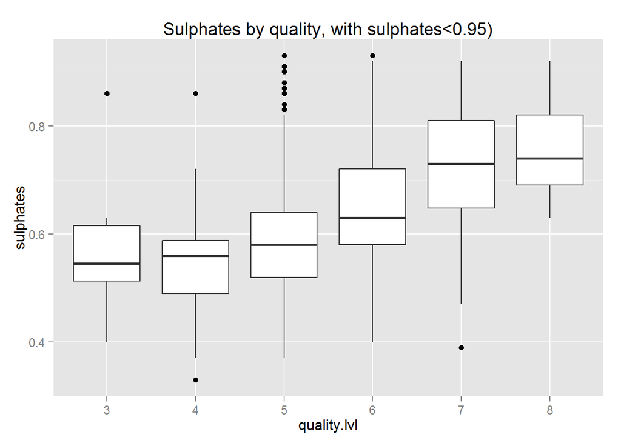

The boxplot shows that the higher the quality, the higher the sulphates.

```
## [1] 0.3471894
```

Let’s now look at sulfurs.

### Chlorides, residual sugar and sulfurs by quality

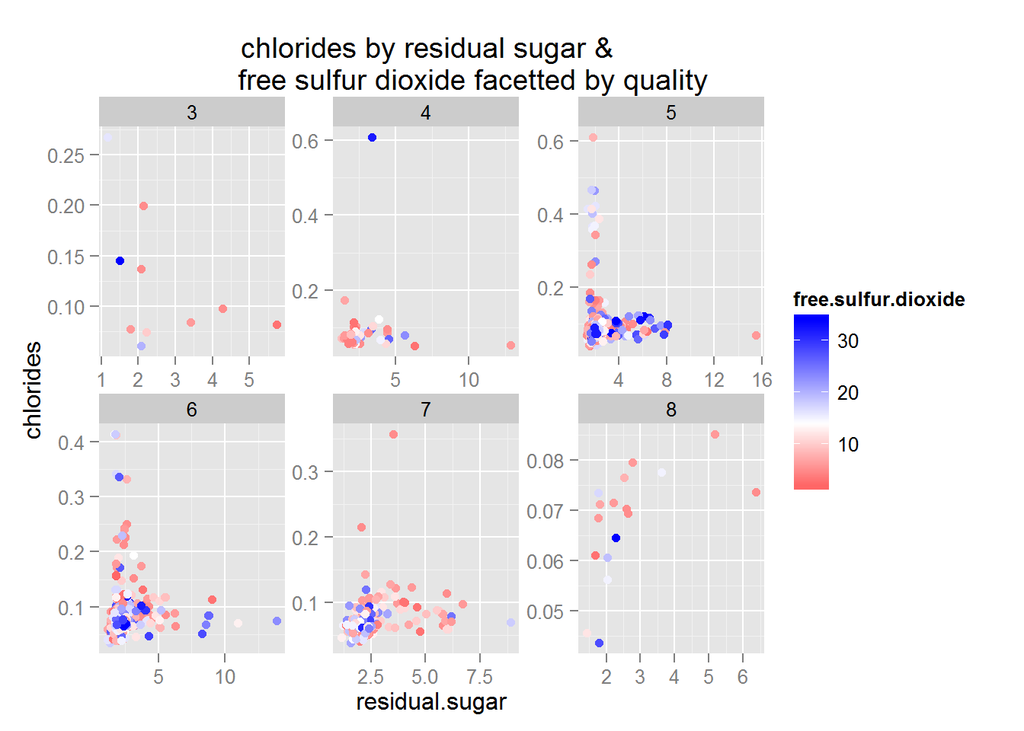

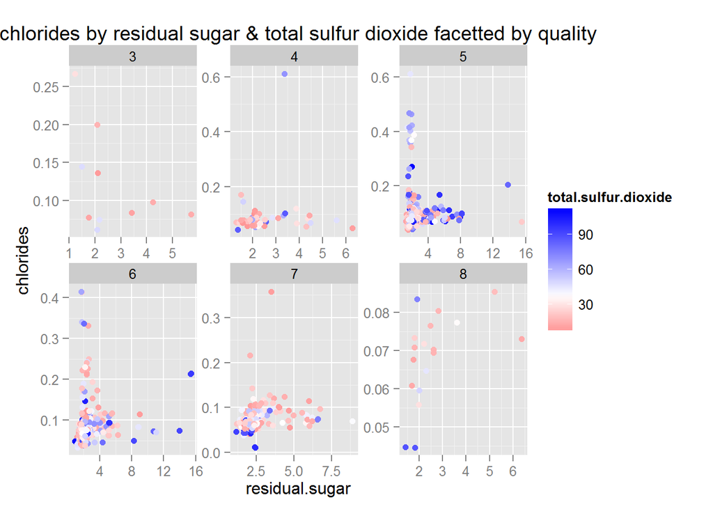

Both plots have sulfur levels showing on all qualities and on all levels of residual.sugar and chlorides. I do not think there is any relationships between those variables.

```
## [1] 0.002799531
```

```
## [1] -0.04926541
```

Correlation are really low:

- 0.003 between residual.sugar_chlorides and free.sulfur.dioxide
- -0.049 between residual.sugar_chlorides and total.sulfur.dioxide

# Final Plots and Summary

First of all, there are outliers in the dataset. I tried to remove them when their value seemed to really be out of range. But it might also underlines the diversity of wines. As I am not sure, the following graphs are based on the whole dataset. All in all, there is not some really strong correlations between quality and the other variables presented here. But I could understood some relationships regarding tastes:

## Vinegar taste is not really looked for

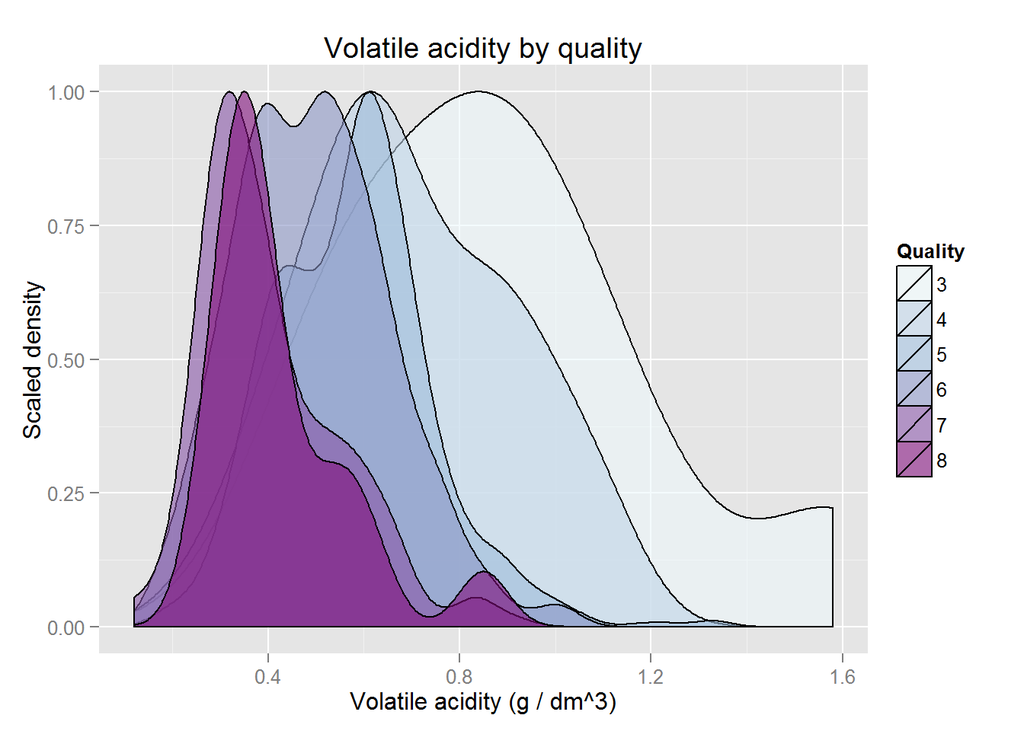

The density were scaled so that the low counts of the extreme quality do affect the overall distribution. As the quality of the wines get higher, the volatile acidity is getting lower. The correlation is quite strong at -0.391. The negative sign signifies that the higher the volatile acidity (and hence the vinegar taste) the lower the quality. It is not always true. This is kind of what we can expect. When you buy cheap wine (which is not always, but most of the time of lower quality) it has most of the time a pugent smell and taste, like vinegar.

## But citric acid is the other way around

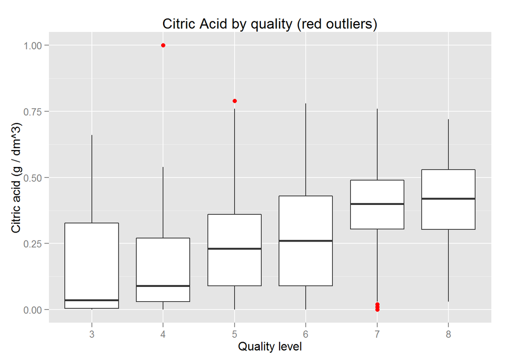

This kind of acid add freshness and flavor. It is confirmed by the boxplot: lower quality wines have less citric acid in general than their higher contourparts. The correlation coefficient is at 0.226. We can group quality into 3 supra group:

1. Quality 3 & 4: low citric acid median at 0.08
2. Quality 5 & 6: median around 0.24
3. Quality 7 & 8: median around 0.4